# DM_TimeSeries

## 本次作業主題，做回歸分析 (使用線性回歸模型)

#### **問題** : 新竹地區2020年10~12月之空氣品質資料，進行時間序列分析&迴歸預測pm2.5值

```python
import os
import pandas as pd

import numpy as np
from sklearn.linear_model import LinearRegression
from sklearn.ensemble import RandomForestRegressor
from sklearn.metrics import mean_absolute_error
import matplotlib.pyplot as plt
import warnings
warnings.filterwarnings("ignore")

path = r'D:\YCHung\Code\DataMining\HW3'
path = r'D:\110-1\DL_HW2\DM'
os.chdir(path)
print(os.getcwd())
# df = pd.read_csv('新竹_2020.csv' , encoding = "gb18030")
df = pd.read_csv(open('新竹_2020.csv'))#, encoding = "gb18030")
df.drop(0,inplace=True)
display(df.head())
```

```
D:\110-1\DL_HW2\DM
```

|  | 測站 | 日期 | 測項 | 00 | 01 | 02 | 03 | 04 | 05 | 06 | ... | 14 | 15 | 16 | 17 | 18 | 19 | 20 | 21 | 22 | 23 |
| --- | --- | --- | --- | --- | --- | --- | --- | --- | --- | --- | --- | --- | --- | --- | --- | --- | --- | --- | --- | --- | --- |
| 1 | 新竹 | 2020/01/01 00:00:00 | AMB_TEMP | 15.2 | 15.2 | 15.3 | 15.3 | 15.3 | 15.4 | 15.5 | ... | 18.1 | 18.2 | 17.9 | 17.3 | 16.7 | 16.4 | 16.2 | 16.1 | 16 | 15.8 |
| 2 | 新竹 | 2020/01/01 00:00:00 | CH4 | 1.74 | 1.74 | 1.77 | 1.78 | 1.77 | 1.77 | 1.77 | ... | 1.78 | 1.78 | 1.77 | 1.8 | 1.81 | 1.82 | 1.85 | 1.83 | 1.92 | 1.94 |
| 3 | 新竹 | 2020/01/01 00:00:00 | CO | 0.28 | 0.25 | 0.24 | 0.22 | 0.2 | 0.19 | 0.2 | ... | 0.28 | 0.29 | 0.28 | 0.34 | 0.39 | 0.41 | 0.46 | 0.49 | 0.58 | 0.52 |
| 4 | 新竹 | 2020/01/01 00:00:00 | NMHC | 0.06 | 0.07 | 0.05 | 0.05 | 0.05 | 0.05 | 0.07 | ... | 0.09 | 0.09 | 0.07 | 0.08 | 0.12 | 0.12 | 0.16 | 0.14 | 0.17 | 0.2 |
| 5 | 新竹 | 2020/01/01 00:00:00 | NO | 0.3 | 0.6 | 0.6 | 0.6 | 0.3 | 0.3 | 0.5 | ... | 1.6 | 1.6 | 1.2 | 0.7 | 0.9 | 1.1 | 1.1 | 1.7 | 1.8 | 1.4 |

5 rows × 27 columns

#### 優化欄位值

```python
Renew_name_list = []
for e in df.columns:
    Renew_name_list.append(e.strip())
Renew_name_list = dict(zip(df.columns,Renew_name_list))
df.rename(columns = Renew_name_list, inplace=True)
df[df =='NR']=0
display(df.columns)
display(df['測項'].apply(lambda x:x.strip()).unique())
# df_train = df['日期'][4933:6031]
# df_valid = df['日期'][6031:]
```

```
Index(['測站', '日期', '測項', '00', '01', '02', '03', '04', '05', '06', '07', '08',
       '09', '10', '11', '12', '13', '14', '15', '16', '17', '18', '19', '20',
       '21', '22', '23'],
      dtype='object')
```

```
array(['AMB_TEMP', 'CH4', 'CO', 'NMHC', 'NO', 'NO2', 'NOx', 'O3', 'PM10',
       'PM2.5', 'RAINFALL', 'RH', 'SO2', 'THC', 'WD_HR', 'WIND_DIREC',
       'WIND_SPEED', 'WS_HR'], dtype=object)
```

## 取出需要的資料

```python
# df_train, df_test 都純取值
month = ['10', '11']
tmp = df['日期'].apply(lambda x: True if x[5:7] in month else False)
df_train = df[tmp]
df_train = df_train.iloc[:,3:]

month = ['12']
tmp = df['日期'].apply(lambda x: True if x[5:7] in month else False)
df_test = df[tmp]
df_test = df_test.iloc[:,3:]
```

### 整理資料格式

#### 建立 Flatten 函數

```python
def FLATTEN(df_train):
    N = df_train.shape[0]//18
    FLATTEN = np.array(df_train.iloc[:18])
    for i in range(1,N):
        FLATTEN = np.hstack((FLATTEN, df_train.iloc[18*i:18*(i+1)]))
    df_FLATTEN = pd.DataFrame(FLATTEN)
    return df_FLATTEN
```

```python
df_Tr = FLATTEN(df_train)
df_Te = FLATTEN(df_test)
```

```python
df_Te.tail(7)
```

|  | 0 | 1 | 2 | 3 | 4 | 5 | 6 | 7 | 8 | 9 | ... | 734 | 735 | 736 | 737 | 738 | 739 | 740 | 741 | 742 | 743 |
| --- | --- | --- | --- | --- | --- | --- | --- | --- | --- | --- | --- | --- | --- | --- | --- | --- | --- | --- | --- | --- | --- |
| 11 | 85 | 86 | 87 | 87 | 86 | 86 | 87 | 86 | 85 | 80 | ... | 58 | 60 | 61 | 62 | 62 | 61 | 61 | 60 | 60 | 62 |
| 12 | 0.5 | 1.9 | 1.8 | 1.8 | 1.8 | 2 | 1.8 | 2.5 | 3.1 | 3.3 | ... | # | # | # | # | # | # | # | # | # | # |
| 13 | 2.01 | 2 | 2.01 | 2.01 | 1.99 | 2.01 | 1.97 | 2.03 | 2.04 | 2.06 | ... | 2.03 | 2.07 | 2.07 | 2.1 | 2.1 | 2.07 | 2.07 | 2.05 | 2.04 | 2.07 |
| 14 | 43 | 45 | 49 | 43 | 50 | 35 | 36 | 34 | 34 | 37 | ... | 54 | 50 | 52 | 45 | 47 | 42 | 42 | 47 | 45 | 44 |
| 15 | 31 | 38 | 40 | 47 | 55 | 37 | 30 | 41 | 35 | 35 | ... | 48 | 43 | 44 | 33 | 50 | 40 | 46 | 46 | 51 | 38 |
| 16 | 4.3 | 4.2 | 3.8 | 3.9 | 4.7 | 5.3 | 4.3 | 4 | 4.6 | 5.3 | ... | 4.5 | 4.4 | 4.2 | 3.8 | 3.7 | 4.7 | 4.5 | 4.4 | 3.9 | 3.9 |
| 17 | 3.5 | 3 | 3 | 3.1 | 3 | 4 | 3.6 | 3.3 | 3.7 | 4 | ... | 3.7 | 3.1 | 3.3 | 3.1 | 2.9 | 3.3 | 3.1 | 2.9 | 2.8 | 2.6 |

7 rows × 744 columns

## 彌補缺失值

#### 需特別注意要先整理好表格才能填補

```python
symbol_list = ['#', '*', 'x', 'A']
def FILLAVE(df_FLATTEN):
    for a in range(0,len(df_FLATTEN)):
        for i in range(1,len(df_FLATTEN.columns)-1):
            j = i-1
            k = i+1
            if sum([str(df_FLATTEN.iloc[a,i]).rfind(sym) for sym in symbol_list])!=-4:
                while sum([str(df_FLATTEN.iloc[a,j]).rfind(sym) for sym in symbol_list])!=-4:
                    j = j-1
                while sum([str(df_FLATTEN.iloc[a,k]).rfind(sym) for sym in symbol_list])!=-4:
                    k = k+1
                    if k>=len(df_FLATTEN.columns)-1: # 在prediction資料上因為末位是未知的，會跑到超出上界
                        k=j
                df_FLATTEN.iloc[a,i] = str((float(df_FLATTEN.iloc[a,j]) + float(df_FLATTEN.iloc[a,k]))/2)
        ## new add in 1117
        if sum([1 for sym in symbol_list if sym in df_FLATTEN.iloc[a,-1]])!=0:
            df_FLATTEN.iloc[a,-1] = df_FLATTEN.iloc[a,-2]
    return df_FLATTEN

df_Train = FILLAVE(df_Tr)
df_Test = FILLAVE(df_Te)
```

```python
indexlist = df['測項'].apply(lambda x:x.strip()).unique()
display(indexlist)
```

```
array(['AMB_TEMP', 'CH4', 'CO', 'NMHC', 'NO', 'NO2', 'NOx', 'O3', 'PM10',
       'PM2.5', 'RAINFALL', 'RH', 'SO2', 'THC', 'WD_HR', 'WIND_DIREC',
       'WIND_SPEED', 'WS_HR'], dtype=object)
```

```python
pm25lst = np.arange(9,df_train.shape[0],18)
len(pm25lst)
df_train.iloc[pm25lst].sum()
df_train.iloc[pm25lst].describe()
```

|  | 00 | 01 | 02 | 03 | 04 | 05 | 06 | 07 | 08 | 09 | ... | 14 | 15 | 16 | 17 | 18 | 19 | 20 | 21 | 22 | 23 |
| --- | --- | --- | --- | --- | --- | --- | --- | --- | --- | --- | --- | --- | --- | --- | --- | --- | --- | --- | --- | --- | --- |
| count | 61 | 61 | 61 | 61 | 61 | 61 | 61 | 61 | 61 | 61 | ... | 61 | 61 | 61 | 61 | 61 | 61 | 61 | 61 | 61 | 61 |
| unique | 22 | 21 | 19 | 23 | 19 | 22 | 21 | 23 | 22 | 22 | ... | 22 | 22 | 21 | 21 | 21 | 22 | 22 | 22 | 24 | 20 |
| top | 9 | 6 | 7 | 10 | 6 | 9 | 7 | 9 | 7 | 6 | ... | 11 | 9 | 8 | 7 | 11 | 9 | 7 | 9 | 11 | 7 |
| freq | 6 | 10 | 10 | 7 | 9 | 7 | 12 | 8 | 8 | 7 | ... | 8 | 9 | 7 | 8 | 6 | 7 | 6 | 8 | 7 | 7 |

4 rows × 24 columns

### 視覺化

- 將所有屬性資料對應時間畫出來
- 觀察每日固定每6小時畫出對應的折線圖
- 從趨勢觀察資料是否與PM2.5走勢有相關性
- 透過計算平均觀察平均在幾點時PM2.5含量最高

#### 視覺化觀察分布情形

- 風越小，累積懸浮粒含量越高
- CO, NO, NOx, PM10 走勢與PM2.5相似

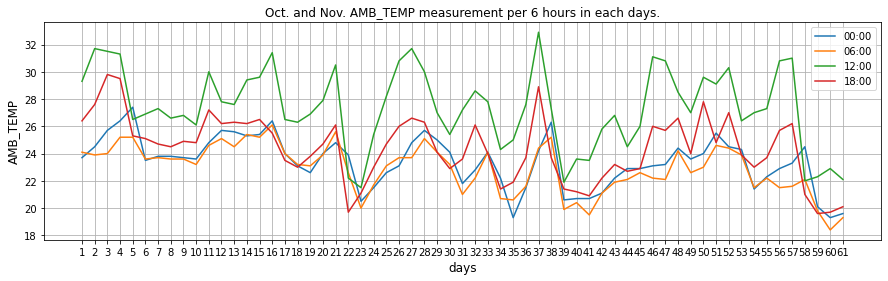

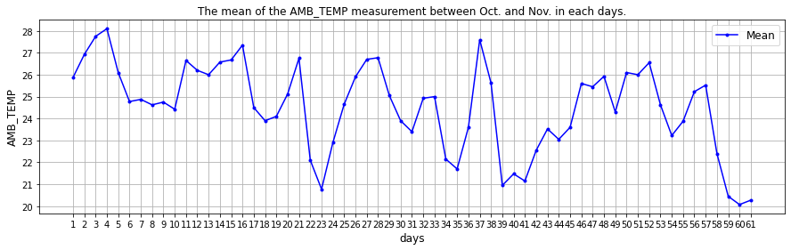

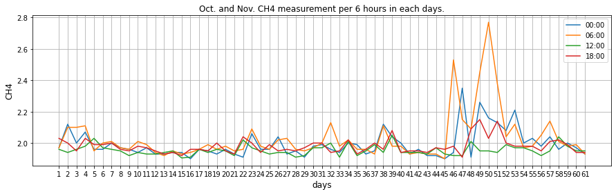

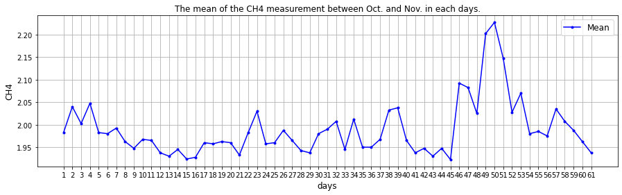

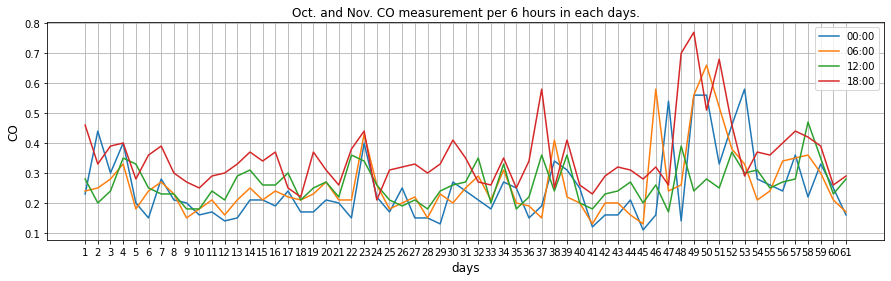

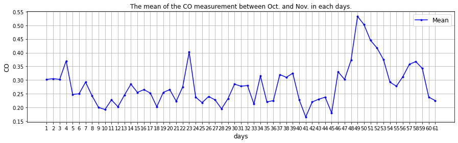

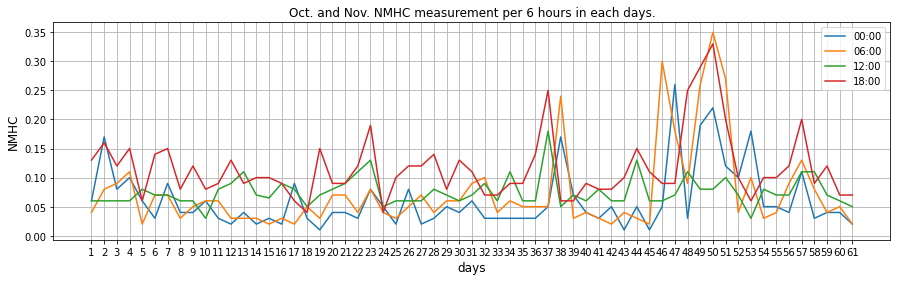

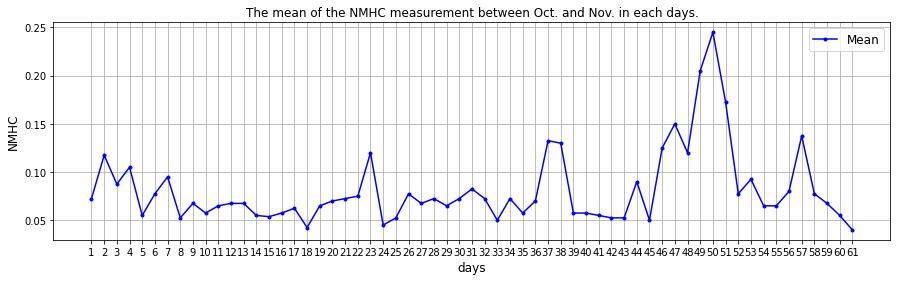

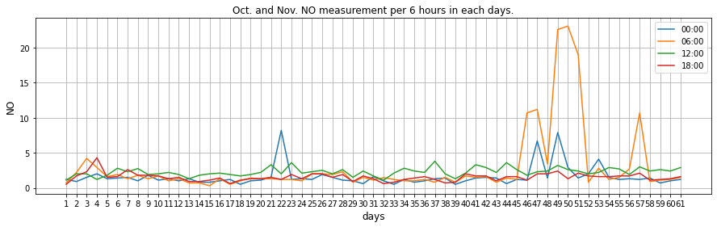

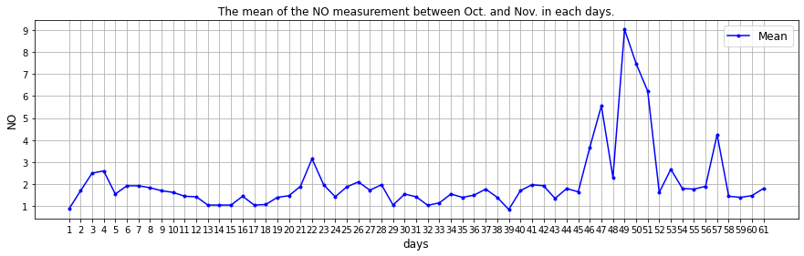

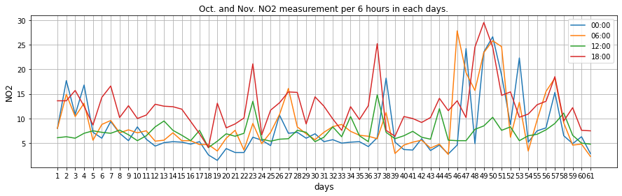

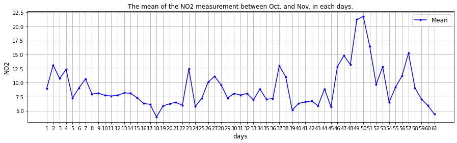

[9 more figures not shown]

```python
num = 9
Mean = 0
per_hour = 6
figsize = (15,4)
fontsize = 12

for num in range(18):
    fig = plt.figure(figsize=figsize)
    for hours in range(0, 24, per_hour):
        x1 = np.arange(hours, df_Train.shape[1],24)
        x = np.arange(1,len(df_Train.iloc[num,x1])+1)

        plt.plot(x, np.float64(df_Tr.iloc[num,x1]))
        Mean += np.float64(df_Tr.iloc[num,x1])
    plt.title(f'Oct. and Nov. {indexlist[num]} measurement per {per_hour} hours in each days.',{"fontsize" : fontsize})
    plt.ylabel(indexlist[num],{"fontsize" : fontsize})
    plt.xlabel('days',{"fontsize" : fontsize})
    plt.xticks(x)
    plt.legend([f'{int(e):02d}:00' for e in range(0, 24, per_hour)])
    plt.grid()
    Mean = Mean/(24//per_hour)

    fig = plt.figure(figsize=figsize)
    plt.title(f'The mean of the {indexlist[num]} measurement between Oct. and Nov. in each days.',{"fontsize" : fontsize})
    plt.ylabel(indexlist[num],{"fontsize" : fontsize})
    plt.xlabel('days',{"fontsize" : fontsize})
    plt.plot(x, Mean,'.-', color='blue')
    plt.xticks(x)
    plt.grid()
    plt.legend(['Mean'],fontsize=12)
    Mean=0
```

```python
# df_Train.iloc[9]
days = df_Train.shape[1]//24
PMmean = 0
for i in range(days):
    PMmean += np.float64(df_Train.iloc[9][24*i:24*(i+1)])
PMmean/=days
```

### 10~11月平均每時刻含有的PM2.5含量圖

```python
figsize = (16,5)
fontsize = 12
x = np.arange(len(PMmean))
fig = plt.figure(figsize=figsize)
plt.title(f'The mean of the PM2.5 measurement between Oct. and Nov. in each days.',{"fontsize" : fontsize})
plt.ylabel('Mean of PM2.5',{"fontsize" : fontsize})
plt.xlabel('Time(24-hour clock)',{"fontsize" : fontsize})
plt.xticks(x)
plt.plot(x, PMmean, color='blue')
plt.legend(['Mean'],fontsize=20)
plt.grid('minor')
```

[output not shown]

```python
df_Train.index, list(df_Train.index), len(df_Train.index)
```

[output not shown]

# 資料敘述

**依序順序如下:**

### SPliting DAta function

```python
def SPDA(df_Train, period, pred, feature=0):
    length = len(df_Train.columns) - pred
    train_x = [ [] for i in range(length)]
    if feature!=1:
        Index = df_Train.index
    else:
        Index = [9]
    for i in range(length):
        for j in Index:
            train_x[i].append(df_Train.loc[j, i:i+period-1])
    train_x = np.float64(train_x).reshape((len(train_x),-1))
    train_y = np.float64(list(df_Train.loc[9,pred:])).reshape(len(df_Train.loc[9,pred:]),1)
    return train_x, train_y

train1_X_6_p6, train_Y_p6 = SPDA(df_Train, period=6, pred=6, feature=1)
train1_X_6_p11, train_Y_p11 = SPDA(df_Train, period=6, pred=11, feature=1)
train18_X_6_p6, train_Y_p6 = SPDA(df_Train, period=6, pred=6, feature=0)
train18_X_6_p11, train_Y_p11 = SPDA(df_Train, period=6, pred=11, feature=0)

test1_X_6_p6, test_Y_p6 = SPDA(df_Test, period=6, pred=6, feature=1)
test1_X_6_p11, test_Y_p11 = SPDA(df_Test, period=6, pred=11, feature=1)
test18_X_6_p6, test_Y_p6 = SPDA(df_Test, period=6, pred=6, feature=0)
test18_X_6_p11, test_Y_p11 = SPDA(df_Test, period=6, pred=11, feature=0)
```

```python
data_list = [(train1_X_6_p6, train_Y_p6, test1_X_6_p6, test_Y_p6),
        (train1_X_6_p11, train_Y_p11, test1_X_6_p11, test_Y_p11),
        (train18_X_6_p6, train_Y_p6, test18_X_6_p6, test_Y_p6),
        (train18_X_6_p11, train_Y_p11, test18_X_6_p11, test_Y_p11)]
```

### Visualize Function

```python
def Plot_the_result(pred_Y, test_Y, hour=10, name='LinearRegression'):
    figsize = (12,4)
    fontsize = 12
    mean_pred_Y = [np.mean(pred_Y[24*i:24*(i+1)]) for i in range(31)]
    mean_test_Y = [np.mean(test_Y[24*i:24*(i+1)]) for i in range(31)]
    x = np.arange(1,len(pred_Y[hour:-1:24])+1)
    fig = plt.figure(figsize=figsize)
    plt.title(f'The prediction of the PM2.5 measurement in Dec. in each days at time {hour:02d}:00.',{"fontsize" : fontsize})
    plt.ylabel('Measure of PM2.5',{"fontsize" : fontsize})
    plt.xlabel(f'Method : {name}' ,{"fontsize" : fontsize})
    plt.xticks(x)
    plt.plot(x, pred_Y[hour:-1:24], color='blue', marker='*', linestyle = 'dashed')
    plt.plot(x, test_Y[hour:-1:24], color='red', marker='o')
    plt.plot(x, mean_pred_Y, color='green', marker='*', linestyle = 'dashed')
    plt.plot(x, mean_test_Y, color='orange', marker='o')
    plt.legend(['pred','real', 'M_pred','M_real'],fontsize=10)
    plt.grid()
```

### LinearRegression

```python
namelst = ['predict 6-th(1 feature)','predict 6-th(18 features)', 'predict 11-th(1 feature)','predict 11-th(18 features)']
loss = []
for idx,lst in enumerate(data_list):
    train_X, train_Y, test_X, test_Y = lst
    lr_model = LinearRegression()
    lr_model.fit(train_X, train_Y)
    pred_Y = lr_model.predict(test_X)
    MAE = mean_absolute_error(test_Y, pred_Y)
    Plot_the_result(pred_Y, test_Y, hour=10, name=namelst[idx])
    loss.append(MAE)
print('The MAE(mean absolute error) is')
print(loss)
```

[output not shown]

### XGBRegressor

```python
import xgboost as xgb
loss = []
for idx,lst in enumerate(data_list):
    train_X, train_Y, test_X, test_Y = lst
    xgb_model = xgb.XGBRegressor(objective='reg:squarederror', verbosity=2)
    xgb_model.fit(train_X, train_Y)
    pred_Y = xgb_model.predict(test_X)
    MAE = mean_absolute_error(test_Y, pred_Y)
    Plot_the_result(pred_Y, test_Y, hour=10, name=namelst[idx])
    loss.append(MAE)
print('The MAE(mean absolute error) is')
print(loss)
```

[output not shown]

#### 參考資料 : https://codingnote.cc/zh-tw/p/103468/